# Extracting predicted amplicons

Carter Hoffman

2020-09-25

# Extracting predicted amplicons

## Data download

### Synonyms of species

Species names have changed in response to advances in bacterial systematics. All currently known species synonyms were downloaded from the Prokaryotic Nomenclature Up-to-Date[^2] (PNU) website on 1/5/2020. PNU includes information down to the strain level, but these entries were consolidated to the species level. For example, entries like *Enterobacter cloacae* and *Enterobacter cloacae dissolvens* are treated as synonyms of *Enterobacter cloacae*.

### Silva search parameters

Sequences were searched using the “[T]” filter setting, and sequences longer than 1450nt with alignment and pintail quality scores greater than 95% were selected. For the species that had no hits, the taxonomic synonym was used as the search query (if the known synonym was available). The species identified as *Corynebacterium sp* had no type strain available, and was excluded from the query set. Species and accession numbers are listed below.

| species | type strain accession | notes |
| --- | --- | --- |
| Actinobaculum schaalii | FJ960443 | as Actinotignum schaali |
| Actinomyces naeslundii | AB618790 |  |
| Actinomyces neuii | AM084229 | Actinomyces neuii subsp. anitratus |
| Actinomyces odontolyticus | AB818950 |  |
| Actinomyces turicensis | X78720 |  |
| Actinomyces urogenitalis | ACFH01000038 | Actinomyces urogenitalis DSM 15434 |
| Aerococcus christensenii | Y17005 |  |
| Aerococcus sanguinicola | AJ276512 |  |
| Aerococcus urinae | M77819 |  |
| Alloscardovia omnicolens | AM419460 |  |
| Anaerococcus octavius | Y07841 |  |
| Bacillus idriensis | AY904033 |  |
| Bacillus infantis | AY904032 |  |
| Bifidobacterium bifidum | S83624 |  |
| Bifidobacterium breve | AB006658 |  |
| Bifidobacterium longum | AP010889 | Bifidobacterium longum subsp. infa… |
| Brevibacterium massiliense | EU086793 | Brevibacterium ravenspurgense |
| Campylobacter ureolyticus | ARGD01000016 | Campylobacter ureolyticus DSM 20703 |
| Corynebacterium amycolatum | X84244 |  |
| Corynebacterium aurimucosum | AJ309207 |  |
| Corynebacterium coyleae | X96497 |  |
| Corynebacterium matruchotii | ACSH02000003 | Corynebacterium matruchotii ATCC 1… |
| Corynebacterium pyruviciproducens | ATBY01000001 |  |
| Corynebacterium riegelii | Y14651 |  |
| Corynebacterium sp. | . | no type spec |
| Corynebacterium tuscaniense | AY677186 |  |
| Dermabacter hominis | X91034 |  |
| Enterobacter asburiae | AB004744 |  |
| Enterobacter cloacae | CP001918 | Enterobacter cloacae subsp. cloaca… |
| Enterococcus faecalis | AB012212 |  |
| Escherichia coli | EU014689 |  |
| Facklamia hominis | AGZD01000007 | Facklamia hominis CCUG 36813 |
| Facklamia ignava | AGZE01000005 | Facklamia ignava CCUG 37419 |
| Gardnerella vaginalis | M58744 | Gardnerella vaginalis ATCC 14018 |
| Globicatella sanguinis | AB680901 | Globicatella sanguinis |
| Gordonia terrae | AB920570 |  |
| Klebsiella pneumoniae | X87276 |  |
| Kocuria rhizophila | Y16264 |  |
| Kytococcus schroeteri | AJ297722 |  |
| Lactobacillus crispatus | AB008206 |  |
| Lactobacillus delbrueckii | AB007908 |  |
| Lactobacillus fermentum | AJ575812 |  |
| Lactobacillus gasseri | AB008209 |  |
| Lactobacillus iners | HE573916 |  |
| Lactobacillus jensenii | AF243176 |  |
| Lactobacillus johnsonii | HE573915 |  |
| Lactobacillus pontis | X76329 |  |
| Lactobacillus rhamnosus | AB008211 |  |
| Micrococcus luteus | CP001628 | Micrococcus luteus NCTC 2665 |
| Moraxella osloensis | FR726160 |  |
| Morganella morganii | AJ301681 | Morganella morganii subsp. morganii |
| Neisseria macacae | HF558383 |  |
| Neisseria perflava | HF558366 |  |
| Neisseria subflava | AJ239291 |  |
| Oligella urethralis | AF133538 |  |
| Propionibacterium acnes | CP006032 | Propionibacterium acnes hdn-1 no type spec |
| Propionibacterium avidum | AGBA01000019 | as Cutibacterium avidum ATCC 25577 |
| Proteus mirabilis | AJ301682 |  |
| Pseudomonas aeruginosa | HE978271 |  |
| Rothia dentocariosa | CP002280 | Rothia dentocariosa ATCC 17931 |
| Rothia mucilaginosa | X87758 |  |
| Staphylococcus epidermidis | AB681292 |  |
| Staphylococcus hominis | X66101 | Staphylococcus hominis subsp. homi… 1 |
| Staphylococcus pettenkoferi | AF322002 |  |
| Staphylococcus saprophyticus | AP008934 | Staphylococcus saprophyticus subsp… |
| Staphylococcus simulans | D83373 |  |
| Staphylococcus warneri | L37603 |  |
| Streptococcus agalactiae | AB023574 |  |
| Streptococcus anginosus | AFIM01000033 |  |
| Streptococcus equinus | AB680295 |  |
| Streptococcus gordonii | AF003931 |  |
| Streptococcus mitis | AF003929 |  |
| Streptococcus oralis | ADMV01000001 |  |
| Streptococcus parasanguinis | AF003933 |  |
| Streptococcus salivarius | AY188352 | Streptococcus salivarius subsp. sa… |
| Streptococcus sanguinis | AF003928 |  |
| Trueperella bernardiae only one seq available | X79224 |  |
| Varibaculum cambriense | AJ428402 |  |
| Veillonella parvula | AB538437 |  |

### pare down results

All these sequences were downloaded and saved in one multi-record FASTA file named arb-silva.de_2019-11-10_id739827.fasta. However, this file also includes several other entries of each species. For example, in addition to the desired type strain *Streptococcus equinus* AB680295, Silva included an additional 6 entries in the download (AB002482.1.1457, AF104116.1.356, AEVB01000043.3380.4915, AF429764.1.1430, AF429765.1.1463 and AJ301607.1.1433). We used the script `src_files/cull_downloads.py` to comb through the Silva download and write the desired type strains to a new file `ktw_16s_type_2019-11-25_34.fna`"`.

```
~>python cull_downloads.py -i arb-silva.de_2019-11-10_id739827_tax_silva.fasta
writing to ktw_16s_type_2019-11-25_34.fna
```

## Alignment

The sequences in the `ktw_16s_type_2019-11-25_34.fna` file is then used to generate a multi-sequence alignement (MSA) of the 16S rRNA gene. We used the program T-Coffee[^3], an alignment program that generates accurate multisequence alignments even when the sequences are from unrelated species[^4]. The program was run with default settings.

```
~$ t_coffee ktw_16s_type_2019-11-25_34.fna -outorder=aligned
```

The output of the program is a guide tree in Newick format (.dnd), an html file of the MSA in a colorized version, and the actual alignment in Clustal format (.aln). The Clustal file will be used to extract the predicted amplicons.

## Extract amplicons

The MSA contains the 16S rRNA sequence of the *E. coli* type strain EU014689, and this will be used as a reference to map the 9 known variable regions onto the remaining 77 species from the Thomas-White dataset. The positions of the variable regions were confirmed through Sliding Window Analysis (see the sliding_window folder).

| variable region | *E. coli* start | *E. coli* stop | MSA start | MSA stop |
| --- | --- | --- | --- | --- |
| V1 | 69 | 99 | 78 | 151 |
| V2 | 137 | 242 | 191 | 333 |
| V3 | 433 | 497 | 528 | 596 |
| V4 | 576 | 682 | 675 | 783 |
| V5 | 822 | 879 | 925 | 986 |
| V6 | 986 | 1043 | 1093 | 1163 |
| V7 | 1117 | 1173 | 1237 | 1297 |
| V8 | 1243 | 1294 | 1369 | 1424 |
| V9 | 1435 | 1465 | 1566 | 1606 |

| paper | name | sequence | direction | E. coli pos | MSA pos | platform |
| --- | --- | --- | --- | --- | --- | --- |
| Kumar 2005 | A17F | GTT TGA TCC TGG CTC AG | forward | 12 | 19 |  |
| Kumar 2011 | 515R | TTA CCG CGG CMG CSG GCA | reverse | 534 | 633 | MiSeq |
| Kumar 2011 | 515F | GTG CCA GCT GCC GCG GTA ATA | forward | 536 | 635 | MiSeq |
| Kumar 2011 | 1114R | GGG GTT GCG CTC GTT GC | reverse | 1116 | 1234 | MiSeq |
| Bukin 2019 | 16S_BV2f | AGT GGC GGA CGG GTG AGT AA | forward | 102 | 154 | MiSeq |
| Walter 2000 | HDA-2 | GTA TTA CCG CGG CTG CTG GCA C | reverse | 497 | 596 | MiSeq |
| Caporaso 2011 | F515 | GTG CCA GCM GCC GCG GTA A | forward | 516 | 616 | pyro |
| Caporaso 2011 | R806 | CCT GAT GHV CCC AWA GAT TA | reverse | 808 | 911 | pyro |
| Graspeuntner 2018 | V3F | CCT ACG GGA GGC AGC AG | forward | 342 | 434 | MiSeq |
| Graspeuntner 2018 | V4R | GGA CTA CHV GGG TWT CTA AT | reverse | 789 | 892 | MiSeq |

[output not shown]

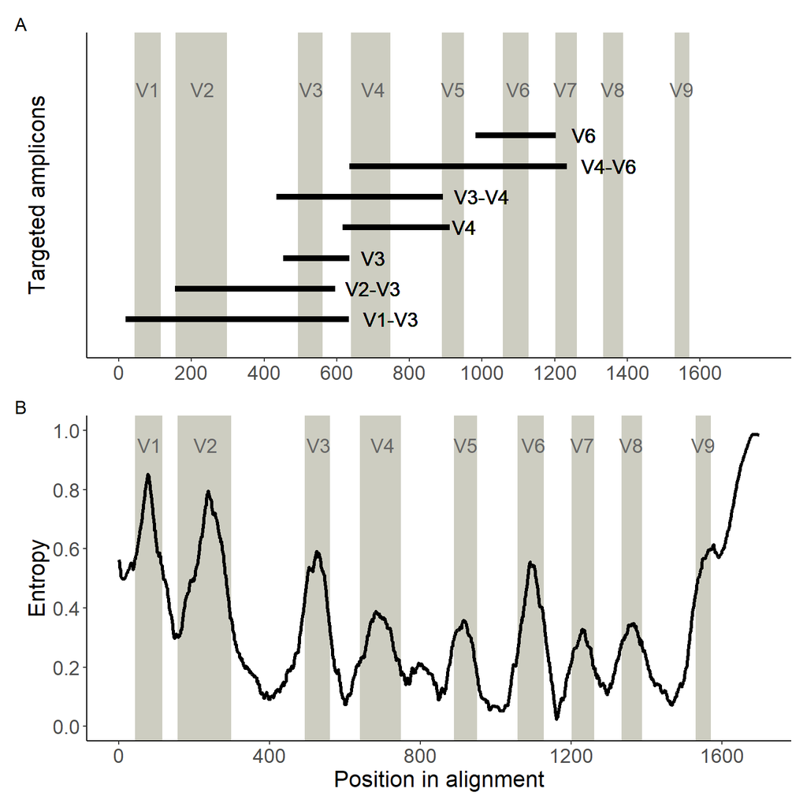

```r
amp_plot / swa_plot + plot_annotation(tag_levels = 'A')
```

The python script `src_files/extract_16s_vr.py` is used to extract the predicted amplicons from the MSA based on the 5’ and 3’ annealing sites of the primer set that would be used in PCR. In the example below, the script takes three arguments: the path to the MSA (ktw_type_16s_2019-11-25/aln/ktw_16s_type_2019-11-25_34.aln), the name of the file that will be written (cap_tpstr), and the start and stop coordinates (516,808). The output is a multi-record FASTA file of the predicted amplicon sequence, for each species in the MSA.

```
~>python extract_16s_vr.py -i ktw_type_16s_2019-11-25/aln/ktw_16s_type_2019-11-25_34.aln -o cap_tpstr -e 516,808
writing to ../processed_data/extracted_16s_regions_2019-11-26/extracted_cap_tpstr_2019-11-26_1550.fna
```

There are two important notes. The first is that you’ll need to determine where a primer set’s annealing sites correspond to the sequence of the *E. coli* type strain EU014689. We used the program UGENE[^5] to search the MSA for the oligo sequence of the primer and transposed to *E. coli*, but there are other methods that will work. The second is that this script producs *predicted* amplicons. It doesn’t check if the primers will actually anneal to a specific species’ 16S rRNA gene sequence. That’s a feature that will probably be added later.

[^1]: Rainey FA. How to Describe New Species of Prokaryotes. In: Methods in Microbiology [Internet]. Elsevier; 2011 [cited 2019 Nov 4]. p. 7–14. Available from: https://linkinghub.elsevier.com/retrieve/pii/B9780123877307000024
[^2]: Parte AC. LPSN – List of Prokaryotic names with Standing in Nomenclature (bacterio.net), 20 years on. Int J Syst Evol Microbiol. 2018 Jun 1;68(6):1825–9.
[^3]: Notredame C, Higgins DG, Heringa J. T-coffee: a novel method for fast and accurate multiple sequence alignment 1 1Edited by J. Thornton. Journal of Molecular Biology. 2000 Sep;302(1):205–17.
[^4]: Edgar RC, Batzoglou S. Multiple sequence alignment. Current Opinion in Structural Biology. 2006 Jun;16(3):368–73.
[^5]: Okonechnikov K, Golosova O, Fursov M. Unipro UGENE: a unified bioinformatics toolkit. Bioinformatics. 2012 Apr;28(8):1166–7.